# IODS course project

Kristiina Räihä

# Introduction to Open Data Science - Course Project

# About the project

The contents of the course Introduction to Open Data Science are **really** interesting, and I’m looking forward to learn more how to use R and to manage data more in a more systematic and efficient way. This is my first touch with GitHub as a user, so there is lot to learn. I hope to keep up with the course!

The link to my IODS-project GitHub page is the following [https://github.com/KristiinaR2/IODS-project]

```r
# This is a so-called "R chunk" where you can write R code.

date()
```

```
## [1] "Sun Dec 12 11:43:58 2021"
```

# Chapter 2: Regression and model validation

```r
date()
```

```
## [1] "Sun Dec 12 11:43:58 2021"
```

## 2.1 Reading the data

The data consists of 166 observations (rows) of 8 variables (columns). The variables are: X (rownumber), Gender (chr: “F”, “M”), Age (int), Attitude (int), deep (dbl), stra (dbl), surf (dbl), Points (int). I mutated the variable gender as a factor, and dropped the X column (the row numbers).

```r
setwd("C:/LocalData/krraiha/Opiskelu HY/Jatko-opinnot/IODS-project/Data")

learning2014_2 <- read.csv("learning2014.csv")

str(learning2014_2)
```

```
## 'data.frame':    166 obs. of  8 variables:
##  $ X       : int  1 2 3 4 5 6 7 8 9 10 ...
##  $ gender  : chr  "F" "M" "F" "M" ...
##  $ Age     : int  53 55 49 53 49 38 50 37 37 42 ...
##  $ Attitude: int  37 31 25 35 37 38 35 29 38 21 ...
##  $ deep    : num  3.58 2.92 3.5 3.5 3.67 ...
##  $ stra    : num  2.58 3.17 2.25 2.25 2.83 ...
##  $ surf    : num  2.58 3.17 2.25 2.25 2.83 ...
##  $ Points  : int  25 12 24 10 22 21 21 31 24 26 ...
```

```r
head(learning2014_2, 10)
```

```
##     X gender Age Attitude     deep     stra     surf Points
## 1   1      F  53       37 3.583333 2.583333 2.583333     25
## 2   2      M  55       31 2.916667 3.166667 3.166667     12
## 3   3      F  49       25 3.500000 2.250000 2.250000     24
## 4   4      M  53       35 3.500000 2.250000 2.250000     10
## 5   5      M  49       37 3.666667 2.833333 2.833333     22
## 6   6      F  38       38 4.750000 2.416667 2.416667     21
## 7   7      M  50       35 3.833333 1.916667 1.916667     21
## 8   8      F  37       29 3.250000 2.833333 2.833333     31
## 9   9      M  37       38 4.333333 2.166667 2.166667     24
## 10 10      F  42       21 4.000000 3.000000 3.000000     26
```

```r
glimpse(learning2014_2)
```

```
## Rows: 166
## Columns: 8
## $ X        <int> 1, 2, 3, 4, 5, 6, 7, 8, 9, 10, 11, 12, 13, 14, 15, 16, 17, 18~
## $ gender   <chr> "F", "M", "F", "M", "M", "F", "M", "F", "M", "F", "M", "F", "~
## $ Age      <int> 53, 55, 49, 53, 49, 38, 50, 37, 37, 42, 37, 34, 34, 34, 35, 3~
## $ Attitude <int> 37, 31, 25, 35, 37, 38, 35, 29, 38, 21, 39, 38, 24, 30, 26, 4~
## $ deep     <dbl> 3.583333, 2.916667, 3.500000, 3.500000, 3.666667, 4.750000, 3~
## $ stra     <dbl> 2.583333, 3.166667, 2.250000, 2.250000, 2.833333, 2.416667, 1~
## $ surf     <dbl> 2.583333, 3.166667, 2.250000, 2.250000, 2.833333, 2.416667, 1~
## $ Points   <int> 25, 12, 24, 10, 22, 21, 21, 31, 24, 26, 31, 31, 23, 25, 21, 3~
```

```r
str(learning2014_2)
```

```
## 'data.frame':    166 obs. of  8 variables:
##  $ X       : int  1 2 3 4 5 6 7 8 9 10 ...
##  $ gender  : chr  "F" "M" "F" "M" ...
##  $ Age     : int  53 55 49 53 49 38 50 37 37 42 ...
##  $ Attitude: int  37 31 25 35 37 38 35 29 38 21 ...
##  $ deep    : num  3.58 2.92 3.5 3.5 3.67 ...
##  $ stra    : num  2.58 3.17 2.25 2.25 2.83 ...
##  $ surf    : num  2.58 3.17 2.25 2.25 2.83 ...
##  $ Points  : int  25 12 24 10 22 21 21 31 24 26 ...
```

```r
#Mutated the gender as a factor.
learning2014_3 <- learning2014_2%>%
  mutate(gender = as.factor(gender))

#deleted the X variable (rownumber)
learning2014_3 <- select(learning2014_3, -X)

str(learning2014_3)
```

```
## 'data.frame':    166 obs. of  7 variables:
##  $ gender  : Factor w/ 2 levels "F","M": 1 2 1 2 2 1 2 1 2 1 ...
##  $ Age     : int  53 55 49 53 49 38 50 37 37 42 ...
##  $ Attitude: int  37 31 25 35 37 38 35 29 38 21 ...
##  $ deep    : num  3.58 2.92 3.5 3.5 3.67 ...
##  $ stra    : num  2.58 3.17 2.25 2.25 2.83 ...
##  $ surf    : num  2.58 3.17 2.25 2.25 2.83 ...
##  $ Points  : int  25 12 24 10 22 21 21 31 24 26 ...
```

## 2.2 Graphical overview of the data

First I explored the data with couple of scatter matrix. What I noticed was that the distributions of age (mean 25) are skewed to the right, as most of the subjects are close to 20 years. The rest of variables are quite normally distributed taking into account the sample size. The gender variable has more observation in F(n=110), than in M(n=56), that might affect the distributions. There are no too high correlations between the variables (collinearity) excluding the the variables surf and stra, that seem to measure same thing, as their correlation is 1?

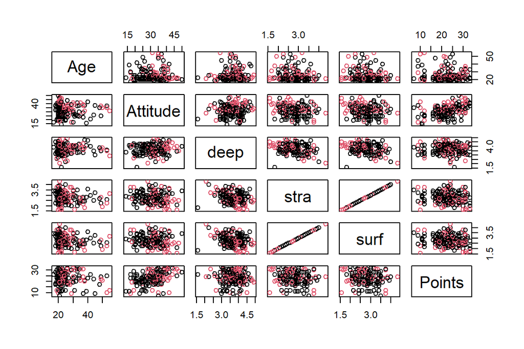

```r
scattermatrix1 <- pairs(learning2014_3[-1], col = learning2014_3$gender)
```

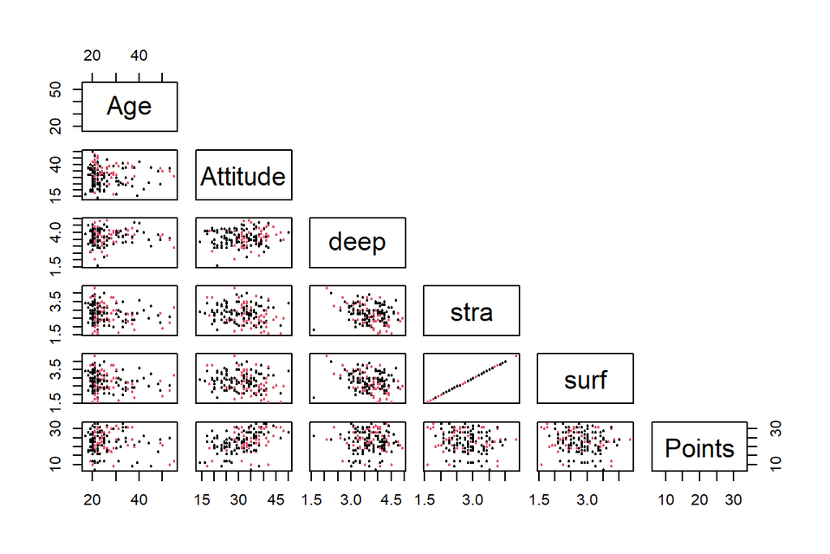

```r
#just for comparison without the upper panel
scattermatrix2 <- pairs(learning2014_3[,c(2:7)], col = learning2014_3$gender, pch = 20, cex=0.4, upper.panel=NULL)
```

```r
scattermatrix2
```

```r
matrix3 <- ggpairs(learning2014_3, mapping = aes(col = gender, alpha = 0.3), lower = list(combo = wrap("facethist", bins = 20)))

gender_n <- learning2014_3%>%
  group_by(gender)%>%
  summarise(n=n())%>%
  ungroup()
```

## 2.3 Fitting the model

First I printed the correlation matrix again, and decided to choose the following variables to the model:

y (dependent) = Points x (explanatory) = Attitude, deep, surf

The first model (fit) indicated that only the attitude (***) was statistically significant explanatory variable. Next I removed the deep and surf, and entered gender and stra (fit1). Still the attitude is the only one that is significant, so I will continue with the model fit2: Points (y)~Attitude (x).

```r
#the correlations in a separate df here as a reminder
correlations <- round(cor(learning2014_3[,c(2:7)]), 2)
correlations
```

```
##            Age Attitude  deep  stra  surf Points
## Age       1.00     0.02  0.03 -0.14 -0.14  -0.09
## Attitude  0.02     1.00  0.11 -0.18 -0.18   0.44
## deep      0.03     0.11  1.00 -0.32 -0.32  -0.01
## stra     -0.14    -0.18 -0.32  1.00  1.00  -0.14
## surf     -0.14    -0.18 -0.32  1.00  1.00  -0.14
## Points   -0.09     0.44 -0.01 -0.14 -0.14   1.00
```

```r
fit <- lm(Points ~ Attitude + deep + surf, data = learning2014_3)
summary(fit)
```

```
##
## Call:
## lm(formula = Points ~ Attitude + deep + surf, data = learning2014_3)
##
## Residuals:
##      Min       1Q   Median       3Q      Max
## -16.9168  -3.1487   0.3667   3.8326  11.3519
##
## Coefficients:
##             Estimate Std. Error t value Pr(>|t|)
## (Intercept) 18.35507    4.71237   3.895 0.000143 ***
## Attitude     0.34661    0.05766   6.011 1.18e-08 ***
## deep        -0.94846    0.79025  -1.200 0.231815
## surf        -1.09114    0.83599  -1.305 0.193669
## ---
## Signif. codes:  0 '***' 0.001 '**' 0.01 '*' 0.05 '.' 0.1 ' ' 1
##
## Residual standard error: 5.313 on 162 degrees of freedom
## Multiple R-squared:  0.2024, Adjusted R-squared:  0.1876
## F-statistic:  13.7 on 3 and 162 DF,  p-value: 5.217e-08
```

```r
#Entered the gender and stra as x.

fit1 <- lm(Points ~ Attitude + gender + stra, data = learning2014_3)
summary(fit1)
```

```
##
## Call:
## lm(formula = Points ~ Attitude + gender + stra, data = learning2014_3)
##
## Residuals:
##      Min       1Q   Median       3Q      Max
## -17.0594  -3.2139   0.5462   3.9774  10.5871
##
## Coefficients:
##             Estimate Std. Error t value Pr(>|t|)
## (Intercept) 14.07420    3.13432   4.490 1.34e-05 ***
## Attitude     0.35265    0.06017   5.861 2.51e-08 ***
## genderM     -0.54387    0.91760  -0.593    0.554
## stra        -0.80968    0.79883  -1.014    0.312
## ---
## Signif. codes:  0 '***' 0.001 '**' 0.01 '*' 0.05 '.' 0.1 ' ' 1
##
## Residual standard error: 5.331 on 162 degrees of freedom
## Multiple R-squared:  0.197,  Adjusted R-squared:  0.1822
## F-statistic: 13.25 on 3 and 162 DF,  p-value: 8.854e-08
```

```r
#Left the Attitude as x.

fit2 <- lm(Points ~ Attitude, data = learning2014_3)
summary(fit2)
```

```
##
## Call:
## lm(formula = Points ~ Attitude, data = learning2014_3)
##
## Residuals:
##      Min       1Q   Median       3Q      Max
## -16.9763  -3.2119   0.4339   4.1534  10.6645
##
## Coefficients:
##             Estimate Std. Error t value Pr(>|t|)
## (Intercept) 11.63715    1.83035   6.358 1.95e-09 ***
## Attitude     0.35255    0.05674   6.214 4.12e-09 ***
## ---
## Signif. codes:  0 '***' 0.001 '**' 0.01 '*' 0.05 '.' 0.1 ' ' 1
##
## Residual standard error: 5.32 on 164 degrees of freedom
## Multiple R-squared:  0.1906, Adjusted R-squared:  0.1856
## F-statistic: 38.61 on 1 and 164 DF,  p-value: 4.119e-09
```

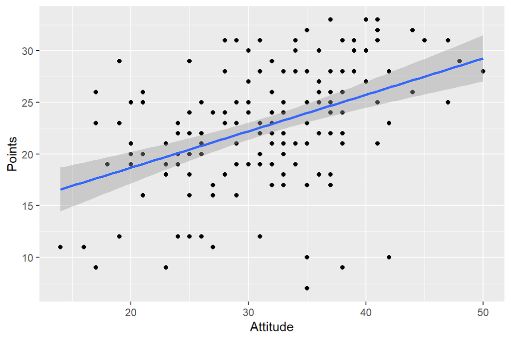

```r
qplot(Attitude, Points, data = learning2014_3) + geom_smooth(method = "lm")
```